# Intro to R: Working with Data

Author

Adam Roberts (adapted from Curt Signorino)

Published

February 11, 2026

## Working Directory

To set the working directory, we will put it in a “setup” chunk. Replace the file path below with the path for your folder. Note for Windows users: use forward slashes. Example: “c:/Users//Desktop/psci200”

```r
# Clear memory
rm(list=ls())
knitr::opts_knit$set(root.dir = "C:/Users/adamd/Documents/psci200")
```

Now you should see your folder’s path when you run the code below:

```r
getwd()
```

```
[1] "C:/Users/adamd/Documents/psci200"
```

## Loading Data Sets

R has many example data sets. To see all the available data sets, we can use `data()`.

```r
data()
```

We can check which objects and data sets we’ve already loaded with `ls()`.

```r
ls()
```

```
character(0)
```

Let’s load a data set called `cars`.

```r
# Load the "cars" dataset
data(cars)
ls()
```

```
[1] "cars"
```

We see that we now have a data frame loaded. Let’s use some commands to better understand the `cars` data set.

```r
# View the first few lines of the data frame
head(cars)
```

```
  speed dist
1     4    2
2     4   10
3     7    4
4     7   22
5     8   16
6     9   10
```

```r
# View the names of variables in the data frame
names(cars)
```

```
[1] "speed" "dist"
```

```r
# Dimensions of the dataset
dim(cars)  # rows, columns
```

```
[1] 50  2
```

```r
nrow(cars) # number of rows
```

```
[1] 50
```

```r
ncol(cars) # number of columns
```

```
[1] 2
```

```r
length(cars) # is this the number of rows?
```

```
[1] 2
```

Now that we understand a bit about the data set as a whole, let’s try looking at a specific variable (column) in the data set.

```r
#speed  # ??
cars$speed  # Refer to variables with $
```

```
 [1]  4  4  7  7  8  9 10 10 10 11 11 12 12 12 12 13 13 13 13 14 14 14 14 15 15
[26] 15 16 16 17 17 17 18 18 18 18 19 19 19 20 20 20 20 20 22 23 24 24 24 24 25
```

```r
cars$dist
```

```
 [1]   2  10   4  22  16  10  18  26  34  17  28  14  20  24  28  26  34  34  46
[20]  26  36  60  80  20  26  54  32  40  32  40  50  42  56  76  84  36  46  68
[39]  32  48  52  56  64  66  54  70  92  93 120  85
```

```r
# Summary statistics
mean(cars$speed)
```

```
[1] 15.4
```

```r
median(cars$dist)
```

```
[1] 36
```

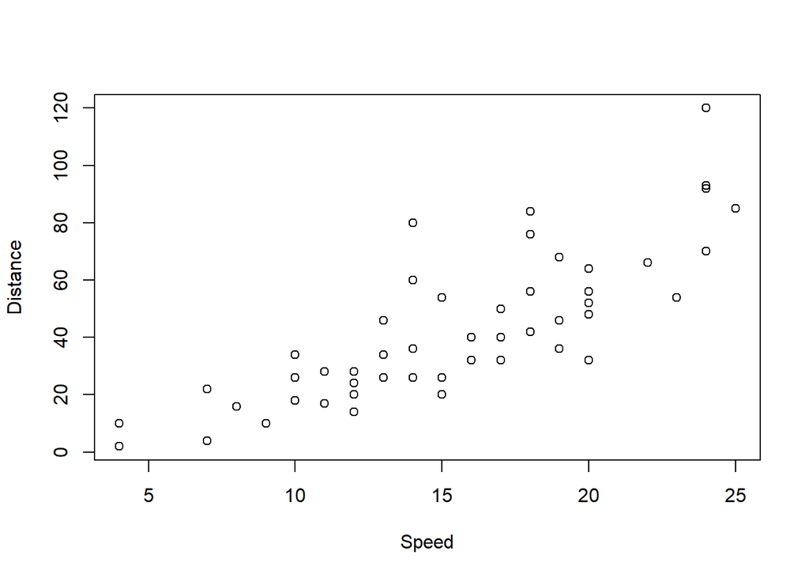

```r
# Plotting
plot(cars$speed, cars$dist, xlab="Speed", ylab="Distance")
```

### Loading an External R Data Set

```r
# obamaecon = {1, 2, 3} where 1 is poor, 2 is neutral, 3 is favorable
# Load the dataset
#load('pew_jan_15.rdata')
ls()
```

```
[1] "cars"
```

```r
# names(pewjan15)
# head(pewjan15)
# pewjan15$age
#
# # Tables
# table(pewjan15$sex, pewjan15$attend)
# tab = table(pewjan15$sex, pewjan15$attend)
# stab = sum(tab)
# tab / stab
```

## Help and Apropos

If you know a command name, but don’t know how to use it, use `help` or `?`.

```r
# help('seq')
# ?seq
```

If you don’t know the exact name of a command but know part of it, use `apropos`.

```r
apropos('tabl')
```

```
 [1] ".S3_methods_table"   "[.table"             "aperm.table"
 [4] "as.data.frame.table" "as.relistable"       "as.table"
 [7] "as.table.default"    "ftable"              "is.relistable"
[10] "is.table"            "margin.table"        "model.tables"
[13] "pairwise.table"      "print.summary.table" "print.table"
[16] "prop.table"          "r2dtable"            "read.ftable"
[19] "read.table"          "summary.table"       "table"
[22] "write.ftable"        "write.table"         "xyTable"
```

Else, use Google or an LLM to find a function that will suit your needs.

# Practice Session

```r
# Add your practice code here
```